# Risk Factor Analysis

## Outcome Variable

**Outcome Variable:** y_rate_wtkg

## Predictor Variables

**Intervention Variable:** impsan

**Adjustment Set:**

- arm
- sex
- W_mage
- meducyrs
- feducyrs
- hhwealth_quart
- hfoodsec
- W_mhtcm
- W_mwtkg
- W_mbmi
- single
- W_nrooms
- W_parity
- impfloor
- safeh20
- delta_W_mage
- delta_meducyrs
- delta_feducyrs
- delta_hhwealth_quart
- delta_hfoodsec
- delta_W_mhtcm
- delta_W_mwtkg
- delta_W_mbmi
- delta_single
- delta_W_nrooms
- delta_W_parity
- delta_impfloor
- delta_safeh20

## Stratifying Variables

The analysis was stratified on these variable(s):

- agecat
- studyid
- country

## Data Summary

| agecat | studyid | country | impsan | n_cell | n |
| --- | --- | --- | --- | --- | --- |
| 0-3 months | COHORTS | GUATEMALA | 1 | 55 | 514 |
| 0-3 months | COHORTS | GUATEMALA | 0 | 459 | 514 |
| 0-3 months | COHORTS | INDIA | 1 | 1808 | 4802 |
| 0-3 months | COHORTS | INDIA | 0 | 2994 | 4802 |
| 0-3 months | CONTENT | PERU | 1 | 25 | 29 |
| 0-3 months | CONTENT | PERU | 0 | 4 | 29 |
| 0-3 months | JiVitA-3 | BANGLADESH | 1 | 13894 | 20270 |
| 0-3 months | JiVitA-3 | BANGLADESH | 0 | 6376 | 20270 |
| 0-3 months | JiVitA-4 | BANGLADESH | 1 | 1386 | 1793 |
| 0-3 months | JiVitA-4 | BANGLADESH | 0 | 407 | 1793 |
| 0-3 months | MAL-ED | BANGLADESH | 1 | 201 | 239 |
| 0-3 months | MAL-ED | BANGLADESH | 0 | 38 | 239 |
| 0-3 months | MAL-ED | BRAZIL | 1 | 206 | 210 |
| 0-3 months | MAL-ED | BRAZIL | 0 | 4 | 210 |
| 0-3 months | MAL-ED | INDIA | 1 | 106 | 230 |
| 0-3 months | MAL-ED | INDIA | 0 | 124 | 230 |
| 0-3 months | MAL-ED | NEPAL | 1 | 229 | 230 |
| 0-3 months | MAL-ED | NEPAL | 0 | 1 | 230 |
| 0-3 months | MAL-ED | PERU | 1 | 64 | 262 |
| 0-3 months | MAL-ED | PERU | 0 | 198 | 262 |
| 0-3 months | MAL-ED | SOUTH AFRICA | 1 | 4 | 248 |
| 0-3 months | MAL-ED | SOUTH AFRICA | 0 | 244 | 248 |
| 0-3 months | MAL-ED | TANZANIA, UNITED REPUBLIC OF | 1 | 0 | 224 |
| 0-3 months | MAL-ED | TANZANIA, UNITED REPUBLIC OF | 0 | 224 | 224 |
| 0-3 months | NIH-Birth | BANGLADESH | 1 | 217 | 565 |
| 0-3 months | NIH-Birth | BANGLADESH | 0 | 348 | 565 |
| 0-3 months | NIH-Crypto | BANGLADESH | 1 | 629 | 714 |
| 0-3 months | NIH-Crypto | BANGLADESH | 0 | 85 | 714 |
| 0-3 months | PROVIDE | BANGLADESH | 1 | 13 | 13 |
| 0-3 months | PROVIDE | BANGLADESH | 0 | 0 | 13 |

[output cut: 198 more lines]

The following strata were considered:

- agecat: 0-3 months, studyid: COHORTS, country: GUATEMALA
- agecat: 0-3 months, studyid: COHORTS, country: INDIA
- agecat: 0-3 months, studyid: CONTENT, country: PERU
- agecat: 0-3 months, studyid: JiVitA-3, country: BANGLADESH
- agecat: 0-3 months, studyid: JiVitA-4, country: BANGLADESH
- agecat: 0-3 months, studyid: MAL-ED, country: BANGLADESH
- agecat: 0-3 months, studyid: MAL-ED, country: BRAZIL
- agecat: 0-3 months, studyid: MAL-ED, country: INDIA
- agecat: 0-3 months, studyid: MAL-ED, country: NEPAL
- agecat: 0-3 months, studyid: MAL-ED, country: PERU
- agecat: 0-3 months, studyid: MAL-ED, country: SOUTH AFRICA
- agecat: 0-3 months, studyid: MAL-ED, country: TANZANIA, UNITED REPUBLIC OF
- agecat: 0-3 months, studyid: NIH-Birth, country: BANGLADESH
- agecat: 0-3 months, studyid: NIH-Crypto, country: BANGLADESH
- agecat: 0-3 months, studyid: PROVIDE, country: BANGLADESH
- agecat: 12-15 months, studyid: COHORTS, country: GUATEMALA
- agecat: 12-15 months, studyid: CONTENT, country: PERU
- agecat: 12-15 months, studyid: JiVitA-4, country: BANGLADESH
- agecat: 12-15 months, studyid: LCNI-5, country: MALAWI
- agecat: 12-15 months, studyid: MAL-ED, country: BANGLADESH
- agecat: 12-15 months, studyid: MAL-ED, country: BRAZIL
- agecat: 12-15 months, studyid: MAL-ED, country: INDIA
- agecat: 12-15 months, studyid: MAL-ED, country: NEPAL
- agecat: 12-15 months, studyid: MAL-ED, country: PERU
- agecat: 12-15 months, studyid: MAL-ED, country: SOUTH AFRICA
- agecat: 12-15 months, studyid: MAL-ED, country: TANZANIA, UNITED REPUBLIC OF
- agecat: 12-15 months, studyid: NIH-Birth, country: BANGLADESH
- agecat: 12-15 months, studyid: NIH-Crypto, country: BANGLADESH
- agecat: 12-15 months, studyid: PROVIDE, country: BANGLADESH
- agecat: 15-18 months, studyid: COHORTS, country: GUATEMALA
- agecat: 15-18 months, studyid: CONTENT, country: PERU
- agecat: 15-18 months, studyid: JiVitA-4, country: BANGLADESH
- agecat: 15-18 months, studyid: LCNI-5, country: MALAWI
- agecat: 15-18 months, studyid: MAL-ED, country: BANGLADESH
- agecat: 15-18 months, studyid: MAL-ED, country: BRAZIL
- agecat: 15-18 months, studyid: MAL-ED, country: INDIA
- agecat: 15-18 months, studyid: MAL-ED, country: NEPAL
- agecat: 15-18 months, studyid: MAL-ED, country: PERU
- agecat: 15-18 months, studyid: MAL-ED, country: SOUTH AFRICA
- agecat: 15-18 months, studyid: MAL-ED, country: TANZANIA, UNITED REPUBLIC OF
- agecat: 15-18 months, studyid: NIH-Birth, country: BANGLADESH
- agecat: 15-18 months, studyid: NIH-Crypto, country: BANGLADESH
- agecat: 15-18 months, studyid: PROVIDE, country: BANGLADESH
- agecat: 18-21 months, studyid: COHORTS, country: GUATEMALA
- agecat: 18-21 months, studyid: CONTENT, country: PERU
- agecat: 18-21 months, studyid: LCNI-5, country: MALAWI
- agecat: 18-21 months, studyid: MAL-ED, country: BANGLADESH
- agecat: 18-21 months, studyid: MAL-ED, country: BRAZIL
- agecat: 18-21 months, studyid: MAL-ED, country: INDIA
- agecat: 18-21 months, studyid: MAL-ED, country: NEPAL
- agecat: 18-21 months, studyid: MAL-ED, country: PERU
- agecat: 18-21 months, studyid: MAL-ED, country: SOUTH AFRICA
- agecat: 18-21 months, studyid: MAL-ED, country: TANZANIA, UNITED REPUBLIC OF
- agecat: 18-21 months, studyid: NIH-Birth, country: BANGLADESH
- agecat: 18-21 months, studyid: NIH-Crypto, country: BANGLADESH
- agecat: 18-21 months, studyid: PROVIDE, country: BANGLADESH
- agecat: 21-24 months, studyid: COHORTS, country: GUATEMALA
- agecat: 21-24 months, studyid: CONTENT, country: PERU
- agecat: 21-24 months, studyid: LCNI-5, country: MALAWI
- agecat: 21-24 months, studyid: MAL-ED, country: BANGLADESH
- agecat: 21-24 months, studyid: MAL-ED, country: BRAZIL
- agecat: 21-24 months, studyid: MAL-ED, country: INDIA
- agecat: 21-24 months, studyid: MAL-ED, country: NEPAL
- agecat: 21-24 months, studyid: MAL-ED, country: PERU
- agecat: 21-24 months, studyid: MAL-ED, country: SOUTH AFRICA
- agecat: 21-24 months, studyid: MAL-ED, country: TANZANIA, UNITED REPUBLIC OF
- agecat: 21-24 months, studyid: NIH-Birth, country: BANGLADESH
- agecat: 21-24 months, studyid: NIH-Crypto, country: BANGLADESH
- agecat: 21-24 months, studyid: PROVIDE, country: BANGLADESH
- agecat: 3-6 months, studyid: COHORTS, country: GUATEMALA
- agecat: 3-6 months, studyid: COHORTS, country: INDIA
- agecat: 3-6 months, studyid: CONTENT, country: PERU
- agecat: 3-6 months, studyid: JiVitA-3, country: BANGLADESH
- agecat: 3-6 months, studyid: JiVitA-4, country: BANGLADESH
- agecat: 3-6 months, studyid: MAL-ED, country: BANGLADESH
- agecat: 3-6 months, studyid: MAL-ED, country: BRAZIL
- agecat: 3-6 months, studyid: MAL-ED, country: INDIA
- agecat: 3-6 months, studyid: MAL-ED, country: NEPAL
- agecat: 3-6 months, studyid: MAL-ED, country: PERU
- agecat: 3-6 months, studyid: MAL-ED, country: SOUTH AFRICA
- agecat: 3-6 months, studyid: MAL-ED, country: TANZANIA, UNITED REPUBLIC OF
- agecat: 3-6 months, studyid: NIH-Birth, country: BANGLADESH
- agecat: 3-6 months, studyid: NIH-Crypto, country: BANGLADESH
- agecat: 3-6 months, studyid: PROVIDE, country: BANGLADESH
- agecat: 6-9 months, studyid: COHORTS, country: GUATEMALA
- agecat: 6-9 months, studyid: COHORTS, country: INDIA
- agecat: 6-9 months, studyid: CONTENT, country: PERU
- agecat: 6-9 months, studyid: JiVitA-4, country: BANGLADESH
- agecat: 6-9 months, studyid: LCNI-5, country: MALAWI
- agecat: 6-9 months, studyid: MAL-ED, country: BANGLADESH
- agecat: 6-9 months, studyid: MAL-ED, country: BRAZIL
- agecat: 6-9 months, studyid: MAL-ED, country: INDIA
- agecat: 6-9 months, studyid: MAL-ED, country: NEPAL
- agecat: 6-9 months, studyid: MAL-ED, country: PERU
- agecat: 6-9 months, studyid: MAL-ED, country: SOUTH AFRICA
- agecat: 6-9 months, studyid: MAL-ED, country: TANZANIA, UNITED REPUBLIC OF
- agecat: 6-9 months, studyid: NIH-Birth, country: BANGLADESH
- agecat: 6-9 months, studyid: NIH-Crypto, country: BANGLADESH
- agecat: 6-9 months, studyid: PROVIDE, country: BANGLADESH
- agecat: 9-12 months, studyid: COHORTS, country: GUATEMALA
- agecat: 9-12 months, studyid: COHORTS, country: INDIA
- agecat: 9-12 months, studyid: CONTENT, country: PERU
- agecat: 9-12 months, studyid: JiVitA-4, country: BANGLADESH
- agecat: 9-12 months, studyid: LCNI-5, country: MALAWI
- agecat: 9-12 months, studyid: MAL-ED, country: BANGLADESH
- agecat: 9-12 months, studyid: MAL-ED, country: BRAZIL
- agecat: 9-12 months, studyid: MAL-ED, country: INDIA
- agecat: 9-12 months, studyid: MAL-ED, country: NEPAL
- agecat: 9-12 months, studyid: MAL-ED, country: PERU
- agecat: 9-12 months, studyid: MAL-ED, country: SOUTH AFRICA
- agecat: 9-12 months, studyid: MAL-ED, country: TANZANIA, UNITED REPUBLIC OF
- agecat: 9-12 months, studyid: NIH-Birth, country: BANGLADESH
- agecat: 9-12 months, studyid: NIH-Crypto, country: BANGLADESH
- agecat: 9-12 months, studyid: PROVIDE, country: BANGLADESH

### Dropped Strata

Some strata were dropped due to rare outcomes:

- agecat: 0-3 months, studyid: CONTENT, country: PERU
- agecat: 0-3 months, studyid: MAL-ED, country: BRAZIL
- agecat: 0-3 months, studyid: MAL-ED, country: NEPAL
- agecat: 0-3 months, studyid: MAL-ED, country: SOUTH AFRICA
- agecat: 0-3 months, studyid: MAL-ED, country: TANZANIA, UNITED REPUBLIC OF
- agecat: 0-3 months, studyid: PROVIDE, country: BANGLADESH
- agecat: 3-6 months, studyid: MAL-ED, country: BRAZIL
- agecat: 3-6 months, studyid: MAL-ED, country: NEPAL
- agecat: 3-6 months, studyid: MAL-ED, country: SOUTH AFRICA
- agecat: 3-6 months, studyid: MAL-ED, country: TANZANIA, UNITED REPUBLIC OF
- agecat: 3-6 months, studyid: PROVIDE, country: BANGLADESH
- agecat: 6-9 months, studyid: LCNI-5, country: MALAWI
- agecat: 6-9 months, studyid: MAL-ED, country: BRAZIL
- agecat: 6-9 months, studyid: MAL-ED, country: NEPAL
- agecat: 6-9 months, studyid: MAL-ED, country: SOUTH AFRICA
- agecat: 6-9 months, studyid: MAL-ED, country: TANZANIA, UNITED REPUBLIC OF
- agecat: 6-9 months, studyid: PROVIDE, country: BANGLADESH
- agecat: 9-12 months, studyid: LCNI-5, country: MALAWI
- agecat: 9-12 months, studyid: MAL-ED, country: BRAZIL
- agecat: 9-12 months, studyid: MAL-ED, country: NEPAL
- agecat: 9-12 months, studyid: MAL-ED, country: SOUTH AFRICA
- agecat: 9-12 months, studyid: MAL-ED, country: TANZANIA, UNITED REPUBLIC OF
- agecat: 9-12 months, studyid: PROVIDE, country: BANGLADESH
- agecat: 12-15 months, studyid: LCNI-5, country: MALAWI
- agecat: 12-15 months, studyid: MAL-ED, country: BRAZIL
- agecat: 12-15 months, studyid: MAL-ED, country: NEPAL
- agecat: 12-15 months, studyid: MAL-ED, country: SOUTH AFRICA
- agecat: 12-15 months, studyid: MAL-ED, country: TANZANIA, UNITED REPUBLIC OF
- agecat: 12-15 months, studyid: PROVIDE, country: BANGLADESH
- agecat: 15-18 months, studyid: LCNI-5, country: MALAWI
- agecat: 15-18 months, studyid: MAL-ED, country: BRAZIL
- agecat: 15-18 months, studyid: MAL-ED, country: NEPAL
- agecat: 15-18 months, studyid: MAL-ED, country: SOUTH AFRICA
- agecat: 15-18 months, studyid: MAL-ED, country: TANZANIA, UNITED REPUBLIC OF
- agecat: 15-18 months, studyid: PROVIDE, country: BANGLADESH
- agecat: 18-21 months, studyid: LCNI-5, country: MALAWI
- agecat: 18-21 months, studyid: MAL-ED, country: BRAZIL
- agecat: 18-21 months, studyid: MAL-ED, country: NEPAL
- agecat: 18-21 months, studyid: MAL-ED, country: SOUTH AFRICA
- agecat: 18-21 months, studyid: MAL-ED, country: TANZANIA, UNITED REPUBLIC OF
- agecat: 18-21 months, studyid: PROVIDE, country: BANGLADESH
- agecat: 21-24 months, studyid: CONTENT, country: PERU
- agecat: 21-24 months, studyid: LCNI-5, country: MALAWI
- agecat: 21-24 months, studyid: MAL-ED, country: BRAZIL
- agecat: 21-24 months, studyid: MAL-ED, country: NEPAL
- agecat: 21-24 months, studyid: MAL-ED, country: SOUTH AFRICA
- agecat: 21-24 months, studyid: MAL-ED, country: TANZANIA, UNITED REPUBLIC OF
- agecat: 21-24 months, studyid: PROVIDE, country: BANGLADESH

## Methods Detail

We’re interested in the causal parameters $E[Y_a]$ for all values of $a \in \mathcal{A}$. These parameters represent the mean outcome if, possibly contrary to fact, we intervened to set all units to have $A=a$. Under the randomization and positivity assumptions, these are identified by the statistical parameters $\psi_a=E_W[E_{Y|A,W}(Y|A=a,W)]$. In addition, we’re interested in the mean of $Y$, $E[Y]$ under no intervention (the observed mean). We will estimate these parameters by using SuperLearner to fit the relevant likelihood factors – $E_{Y|A,W}(Y|A=a,W)$ and $p(A=a|W)$, and then updating our likelihood fit using a joint TMLE.

For unadjusted analyses ($W=\{\}$), initial likelihoods were estimated using Lrnr_glm to estimate the simple $E(Y|A)$ and Lrnr_mean to estimate $p(A)$. For adjusted analyses, a small library containing Lrnr_glmnet, Lrnr_xgboost, and Lrnr_mean was used.

Having estimated these parameters, we will then use the delta method to estimate relative risks and attributable risks relative to a prespecified baseline level of $A$.

# Results Detail

## Results Plots

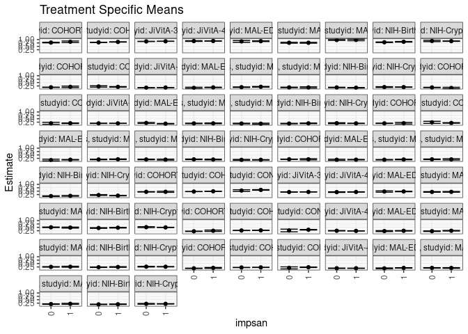

[figure not shown]

[figure not shown]

## Results Table

### Parameter: TSM

| agecat | studyid | country | intervention_level | baseline_level | estimate | ci_lower | ci_upper |
| --- | --- | --- | --- | --- | --- | --- | --- |
| 0-3 months | COHORTS | GUATEMALA | 1 | NA | 0.8378424 | 0.7805614 | 0.8951233 |
| 0-3 months | COHORTS | GUATEMALA | 0 | NA | 0.7795414 | 0.7567757 | 0.8023071 |
| 0-3 months | COHORTS | INDIA | 1 | NA | 0.8250454 | 0.8152248 | 0.8348659 |
| 0-3 months | COHORTS | INDIA | 0 | NA | 0.7936526 | 0.7863180 | 0.8009873 |
| 0-3 months | JiVitA-3 | BANGLADESH | 1 | NA | 0.8723977 | 0.8686726 | 0.8761228 |
| 0-3 months | JiVitA-3 | BANGLADESH | 0 | NA | 0.8633758 | 0.8568799 | 0.8698717 |
| 0-3 months | JiVitA-4 | BANGLADESH | 1 | NA | 0.8942601 | 0.8827288 | 0.9057914 |
| 0-3 months | JiVitA-4 | BANGLADESH | 0 | NA | 0.8891319 | 0.8637830 | 0.9144808 |
| 0-3 months | MAL-ED | BANGLADESH | 1 | NA | 0.8808465 | 0.8548713 | 0.9068216 |
| 0-3 months | MAL-ED | BANGLADESH | 0 | NA | 0.8644225 | 0.7981198 | 0.9307253 |
| 0-3 months | MAL-ED | INDIA | 1 | NA | 0.7641970 | 0.7337726 | 0.7946215 |
| 0-3 months | MAL-ED | INDIA | 0 | NA | 0.7652844 | 0.7319639 | 0.7986049 |
| 0-3 months | MAL-ED | PERU | 1 | NA | 0.9739759 | 0.9173528 | 1.0305990 |
| 0-3 months | MAL-ED | PERU | 0 | NA | 0.9668394 | 0.9364084 | 0.9972704 |
| 0-3 months | NIH-Birth | BANGLADESH | 1 | NA | 0.8383046 | 0.8150392 | 0.8615700 |
| 0-3 months | NIH-Birth | BANGLADESH | 0 | NA | 0.8013837 | 0.7792084 | 0.8235591 |
| 0-3 months | NIH-Crypto | BANGLADESH | 1 | NA | 0.8827077 | 0.8673700 | 0.8980454 |
| 0-3 months | NIH-Crypto | BANGLADESH | 0 | NA | 0.8961319 | 0.8473258 | 0.9449380 |
| 3-6 months | COHORTS | GUATEMALA | 1 | NA | 0.4524411 | 0.4117024 | 0.4931799 |
| 3-6 months | COHORTS | GUATEMALA | 0 | NA | 0.4500362 | 0.4358940 | 0.4641785 |
| 3-6 months | COHORTS | INDIA | 1 | NA | 0.4890142 | 0.4812600 | 0.4967684 |
| 3-6 months | COHORTS | INDIA | 0 | NA | 0.4680538 | 0.4622527 | 0.4738550 |
| 3-6 months | CONTENT | PERU | 1 | NA | 0.5907543 | 0.5685922 | 0.6129163 |
| 3-6 months | CONTENT | PERU | 0 | NA | 0.5433311 | 0.4815811 | 0.6050811 |
| 3-6 months | JiVitA-3 | BANGLADESH | 1 | NA | 0.4420363 | 0.4384887 | 0.4455839 |
| 3-6 months | JiVitA-3 | BANGLADESH | 0 | NA | 0.4345710 | 0.4278975 | 0.4412445 |
| 3-6 months | JiVitA-4 | BANGLADESH | 1 | NA | 0.4404151 | 0.4300643 | 0.4507659 |
| 3-6 months | JiVitA-4 | BANGLADESH | 0 | NA | 0.4283993 | 0.4059853 | 0.4508132 |
| 3-6 months | MAL-ED | BANGLADESH | 1 | NA | 0.4755712 | 0.4576048 | 0.4935376 |
| 3-6 months | MAL-ED | BANGLADESH | 0 | NA | 0.4722408 | 0.4228873 | 0.5215944 |

[output cut: 102 more lines]

### Parameter: E(Y)

| agecat | studyid | country | intervention_level | baseline_level | estimate | ci_lower | ci_upper |
| --- | --- | --- | --- | --- | --- | --- | --- |
| 0-3 months | COHORTS | GUATEMALA | NA | NA | 0.7842946 | 0.7633006 | 0.8052885 |
| 0-3 months | COHORTS | INDIA | NA | NA | 0.8055731 | 0.8001316 | 0.8110146 |
| 0-3 months | JiVitA-3 | BANGLADESH | NA | NA | 0.8710593 | 0.8679755 | 0.8741431 |
| 0-3 months | JiVitA-4 | BANGLADESH | NA | NA | 0.8897517 | 0.8792503 | 0.9002532 |
| 0-3 months | MAL-ED | BANGLADESH | NA | NA | 0.8772390 | 0.8535646 | 0.9009134 |
| 0-3 months | MAL-ED | INDIA | NA | NA | 0.7620085 | 0.7394216 | 0.7845954 |
| 0-3 months | MAL-ED | PERU | NA | NA | 0.9689288 | 0.9429768 | 0.9948807 |
| 0-3 months | NIH-Birth | BANGLADESH | NA | NA | 0.8163500 | 0.7995330 | 0.8331670 |
| 0-3 months | NIH-Crypto | BANGLADESH | NA | NA | 0.8845080 | 0.8697896 | 0.8992264 |
| 3-6 months | COHORTS | GUATEMALA | NA | NA | 0.4507062 | 0.4376433 | 0.4637691 |
| 3-6 months | COHORTS | INDIA | NA | NA | 0.4758823 | 0.4714157 | 0.4803490 |
| 3-6 months | CONTENT | PERU | NA | NA | 0.5883623 | 0.5672770 | 0.6094476 |
| 3-6 months | JiVitA-3 | BANGLADESH | NA | NA | 0.4413966 | 0.4384254 | 0.4443678 |
| 3-6 months | JiVitA-4 | BANGLADESH | NA | NA | 0.4391710 | 0.4303780 | 0.4479640 |
| 3-6 months | MAL-ED | BANGLADESH | NA | NA | 0.4746501 | 0.4579760 | 0.4913241 |
| 3-6 months | MAL-ED | INDIA | NA | NA | 0.4449792 | 0.4272939 | 0.4626645 |
| 3-6 months | MAL-ED | PERU | NA | NA | 0.4981398 | 0.4788320 | 0.5174477 |
| 3-6 months | NIH-Birth | BANGLADESH | NA | NA | 0.4593975 | 0.4422221 | 0.4765729 |
| 3-6 months | NIH-Crypto | BANGLADESH | NA | NA | 0.4982529 | 0.4871014 | 0.5094044 |
| 6-9 months | COHORTS | GUATEMALA | NA | NA | 0.2132733 | 0.2018429 | 0.2247038 |
| 6-9 months | COHORTS | INDIA | NA | NA | 0.2732584 | 0.2685932 | 0.2779236 |
| 6-9 months | CONTENT | PERU | NA | NA | 0.3201718 | 0.3007014 | 0.3396422 |
| 6-9 months | JiVitA-4 | BANGLADESH | NA | NA | 0.2398525 | 0.2345783 | 0.2451267 |
| 6-9 months | MAL-ED | BANGLADESH | NA | NA | 0.2428552 | 0.2283339 | 0.2573765 |
| 6-9 months | MAL-ED | INDIA | NA | NA | 0.2329150 | 0.2179398 | 0.2478901 |
| 6-9 months | MAL-ED | PERU | NA | NA | 0.2596511 | 0.2439596 | 0.2753427 |
| 6-9 months | NIH-Birth | BANGLADESH | NA | NA | 0.2362596 | 0.2225288 | 0.2499904 |
| 6-9 months | NIH-Crypto | BANGLADESH | NA | NA | 0.2668023 | 0.2561807 | 0.2774239 |
| 9-12 months | COHORTS | GUATEMALA | NA | NA | 0.1506988 | 0.1402747 | 0.1611229 |
| 9-12 months | COHORTS | INDIA | NA | NA | 0.2137973 | 0.2089688 | 0.2186259 |
| 9-12 months | CONTENT | PERU | NA | NA | 0.2245187 | 0.2063866 | 0.2426509 |
| 9-12 months | JiVitA-4 | BANGLADESH | NA | NA | 0.1545123 | 0.1502488 | 0.1587759 |
| 9-12 months | MAL-ED | BANGLADESH | NA | NA | 0.1730346 | 0.1593686 | 0.1867006 |
| 9-12 months | MAL-ED | INDIA | NA | NA | 0.1787090 | 0.1645315 | 0.1928865 |
| 9-12 months | MAL-ED | PERU | NA | NA | 0.1877302 | 0.1721772 | 0.2032832 |
| 9-12 months | NIH-Birth | BANGLADESH | NA | NA | 0.1636213 | 0.1504841 | 0.1767585 |
| 9-12 months | NIH-Crypto | BANGLADESH | NA | NA | 0.1982735 | 0.1877823 | 0.2087647 |
| 12-15 months | COHORTS | GUATEMALA | NA | NA | 0.1509490 | 0.1404302 | 0.1614679 |
| 12-15 months | CONTENT | PERU | NA | NA | 0.1810771 | 0.1624014 | 0.1997528 |
| 12-15 months | JiVitA-4 | BANGLADESH | NA | NA | 0.1304576 | 0.1263404 | 0.1345747 |
| 12-15 months | MAL-ED | BANGLADESH | NA | NA | 0.1353586 | 0.1195861 | 0.1511312 |
| 12-15 months | MAL-ED | INDIA | NA | NA | 0.1737542 | 0.1580843 | 0.1894241 |
| 12-15 months | MAL-ED | PERU | NA | NA | 0.1412986 | 0.1241913 | 0.1584059 |
| 12-15 months | NIH-Birth | BANGLADESH | NA | NA | 0.1305063 | 0.1184818 | 0.1425307 |
| 12-15 months | NIH-Crypto | BANGLADESH | NA | NA | 0.1649159 | 0.1542644 | 0.1755674 |
| 15-18 months | COHORTS | GUATEMALA | NA | NA | 0.1376203 | 0.1254069 | 0.1498336 |
| 15-18 months | CONTENT | PERU | NA | NA | 0.1711673 | 0.1527815 | 0.1895531 |
| 15-18 months | JiVitA-4 | BANGLADESH | NA | NA | 0.1595310 | 0.1548323 | 0.1642296 |
| 15-18 months | MAL-ED | BANGLADESH | NA | NA | 0.1427882 | 0.1271818 | 0.1583946 |
| 15-18 months | MAL-ED | INDIA | NA | NA | 0.1620281 | 0.1470182 | 0.1770381 |
| 15-18 months | MAL-ED | PERU | NA | NA | 0.1449378 | 0.1257292 | 0.1641464 |
| 15-18 months | NIH-Birth | BANGLADESH | NA | NA | 0.1529843 | 0.1384423 | 0.1675263 |
| 15-18 months | NIH-Crypto | BANGLADESH | NA | NA | 0.1608018 | 0.1501273 | 0.1714764 |
| 18-21 months | COHORTS | GUATEMALA | NA | NA | 0.1624730 | 0.1508586 | 0.1740875 |
| 18-21 months | CONTENT | PERU | NA | NA | 0.1921646 | 0.1732990 | 0.2110302 |
| 18-21 months | MAL-ED | BANGLADESH | NA | NA | 0.1427146 | 0.1257942 | 0.1596351 |
| 18-21 months | MAL-ED | INDIA | NA | NA | 0.1741118 | 0.1592007 | 0.1890230 |
| 18-21 months | MAL-ED | PERU | NA | NA | 0.1632287 | 0.1439532 | 0.1825042 |
| 18-21 months | NIH-Birth | BANGLADESH | NA | NA | 0.1724392 | 0.1563209 | 0.1885575 |
| 18-21 months | NIH-Crypto | BANGLADESH | NA | NA | 0.1417284 | 0.1308558 | 0.1526011 |
| 21-24 months | COHORTS | GUATEMALA | NA | NA | 0.1872542 | 0.1759502 | 0.1985583 |
| 21-24 months | MAL-ED | BANGLADESH | NA | NA | 0.1521155 | 0.1369898 | 0.1672413 |
| 21-24 months | MAL-ED | INDIA | NA | NA | 0.1561228 | 0.1429524 | 0.1692932 |
| 21-24 months | MAL-ED | PERU | NA | NA | 0.1789625 | 0.1588192 | 0.1991058 |
| 21-24 months | NIH-Birth | BANGLADESH | NA | NA | 0.1419730 | 0.1267767 | 0.1571693 |
| 21-24 months | NIH-Crypto | BANGLADESH | NA | NA | 0.1750178 | 0.1622174 | 0.1878182 |

### Parameter: ATE

| agecat | studyid | country | intervention_level | baseline_level | estimate | ci_lower | ci_upper |
| --- | --- | --- | --- | --- | --- | --- | --- |
| 0-3 months | COHORTS | GUATEMALA | 1 | 1 | 0.0000000 | 0.0000000 | 0.0000000 |
| 0-3 months | COHORTS | GUATEMALA | 0 | 1 | -0.0583010 | -0.1196125 | 0.0030105 |
| 0-3 months | COHORTS | INDIA | 1 | 1 | 0.0000000 | 0.0000000 | 0.0000000 |
| 0-3 months | COHORTS | INDIA | 0 | 1 | -0.0313927 | -0.0435835 | -0.0192019 |
| 0-3 months | JiVitA-3 | BANGLADESH | 1 | 1 | 0.0000000 | 0.0000000 | 0.0000000 |
| 0-3 months | JiVitA-3 | BANGLADESH | 0 | 1 | -0.0090219 | -0.0159087 | -0.0021351 |
| 0-3 months | JiVitA-4 | BANGLADESH | 1 | 1 | 0.0000000 | 0.0000000 | 0.0000000 |
| 0-3 months | JiVitA-4 | BANGLADESH | 0 | 1 | -0.0051282 | -0.0321598 | 0.0219035 |
| 0-3 months | MAL-ED | BANGLADESH | 1 | 1 | 0.0000000 | 0.0000000 | 0.0000000 |
| 0-3 months | MAL-ED | BANGLADESH | 0 | 1 | -0.0164239 | -0.0876746 | 0.0548267 |
| 0-3 months | MAL-ED | INDIA | 1 | 1 | 0.0000000 | 0.0000000 | 0.0000000 |
| 0-3 months | MAL-ED | INDIA | 0 | 1 | 0.0010874 | -0.0442596 | 0.0464343 |
| 0-3 months | MAL-ED | PERU | 1 | 1 | 0.0000000 | 0.0000000 | 0.0000000 |
| 0-3 months | MAL-ED | PERU | 0 | 1 | -0.0071365 | -0.0713686 | 0.0570956 |
| 0-3 months | NIH-Birth | BANGLADESH | 1 | 1 | 0.0000000 | 0.0000000 | 0.0000000 |
| 0-3 months | NIH-Birth | BANGLADESH | 0 | 1 | -0.0369209 | -0.0682115 | -0.0056303 |
| 0-3 months | NIH-Crypto | BANGLADESH | 1 | 1 | 0.0000000 | 0.0000000 | 0.0000000 |
| 0-3 months | NIH-Crypto | BANGLADESH | 0 | 1 | 0.0134242 | -0.0375430 | 0.0643914 |
| 3-6 months | COHORTS | GUATEMALA | 1 | 1 | 0.0000000 | 0.0000000 | 0.0000000 |
| 3-6 months | COHORTS | GUATEMALA | 0 | 1 | -0.0024049 | -0.0455362 | 0.0407264 |
| 3-6 months | COHORTS | INDIA | 1 | 1 | 0.0000000 | 0.0000000 | 0.0000000 |
| 3-6 months | COHORTS | INDIA | 0 | 1 | -0.0209604 | -0.0305149 | -0.0114059 |
| 3-6 months | CONTENT | PERU | 1 | 1 | 0.0000000 | 0.0000000 | 0.0000000 |
| 3-6 months | CONTENT | PERU | 0 | 1 | -0.0474232 | -0.1128962 | 0.0180498 |
| 3-6 months | JiVitA-3 | BANGLADESH | 1 | 1 | 0.0000000 | 0.0000000 | 0.0000000 |
| 3-6 months | JiVitA-3 | BANGLADESH | 0 | 1 | -0.0074653 | -0.0149425 | 0.0000119 |
| 3-6 months | JiVitA-4 | BANGLADESH | 1 | 1 | 0.0000000 | 0.0000000 | 0.0000000 |
| 3-6 months | JiVitA-4 | BANGLADESH | 0 | 1 | -0.0120158 | -0.0369200 | 0.0128883 |
| 3-6 months | MAL-ED | BANGLADESH | 1 | 1 | 0.0000000 | 0.0000000 | 0.0000000 |
| 3-6 months | MAL-ED | BANGLADESH | 0 | 1 | -0.0033304 | -0.0564499 | 0.0497892 |

[output cut: 102 more lines]

### Parameter: PAR

| agecat | studyid | country | intervention_level | baseline_level | estimate | ci_lower | ci_upper |
| --- | --- | --- | --- | --- | --- | --- | --- |
| 0-3 months | COHORTS | GUATEMALA | 1 | NA | -0.0535478 | -0.1092889 | 0.0021933 |
| 0-3 months | COHORTS | INDIA | 1 | NA | -0.0194722 | -0.0276404 | -0.0113041 |
| 0-3 months | JiVitA-3 | BANGLADESH | 1 | NA | -0.0013384 | -0.0032846 | 0.0006078 |
| 0-3 months | JiVitA-4 | BANGLADESH | 1 | NA | -0.0045084 | -0.0108440 | 0.0018273 |
| 0-3 months | MAL-ED | BANGLADESH | 1 | NA | -0.0036075 | -0.0142054 | 0.0069905 |
| 0-3 months | MAL-ED | INDIA | 1 | NA | -0.0021885 | -0.0264127 | 0.0220356 |
| 0-3 months | MAL-ED | PERU | 1 | NA | -0.0050471 | -0.0557313 | 0.0456370 |
| 0-3 months | NIH-Birth | BANGLADESH | 1 | NA | -0.0219546 | -0.0413576 | -0.0025517 |
| 0-3 months | NIH-Crypto | BANGLADESH | 1 | NA | 0.0018003 | -0.0041063 | 0.0077069 |
| 3-6 months | COHORTS | GUATEMALA | 1 | NA | -0.0017349 | -0.0411060 | 0.0376361 |
| 3-6 months | COHORTS | INDIA | 1 | NA | -0.0131319 | -0.0195043 | -0.0067595 |
| 3-6 months | CONTENT | PERU | 1 | NA | -0.0023919 | -0.0067112 | 0.0019273 |
| 3-6 months | JiVitA-3 | BANGLADESH | 1 | NA | -0.0006397 | -0.0026015 | 0.0013221 |
| 3-6 months | JiVitA-4 | BANGLADESH | 1 | NA | -0.0012441 | -0.0064079 | 0.0039197 |
| 3-6 months | MAL-ED | BANGLADESH | 1 | NA | -0.0009211 | -0.0092982 | 0.0074560 |
| 3-6 months | MAL-ED | INDIA | 1 | NA | -0.0037762 | -0.0233811 | 0.0158287 |
| 3-6 months | MAL-ED | PERU | 1 | NA | 0.0163526 | -0.0181890 | 0.0508941 |
| 3-6 months | NIH-Birth | BANGLADESH | 1 | NA | -0.0151412 | -0.0369318 | 0.0066494 |
| 3-6 months | NIH-Crypto | BANGLADESH | 1 | NA | 0.0025678 | -0.0018115 | 0.0069471 |
| 6-9 months | COHORTS | GUATEMALA | 1 | NA | -0.0363243 | -0.0835042 | 0.0108556 |
| 6-9 months | COHORTS | INDIA | 1 | NA | -0.0048391 | -0.0115946 | 0.0019163 |
| 6-9 months | CONTENT | PERU | 1 | NA | -0.0031631 | -0.0088174 | 0.0024913 |
| 6-9 months | JiVitA-4 | BANGLADESH | 1 | NA | 0.0012076 | -0.0019531 | 0.0043684 |
| 6-9 months | MAL-ED | BANGLADESH | 1 | NA | -0.0038915 | -0.0095935 | 0.0018104 |
| 6-9 months | MAL-ED | INDIA | 1 | NA | -0.0179904 | -0.0346858 | -0.0012950 |
| 6-9 months | MAL-ED | PERU | 1 | NA | -0.0050334 | -0.0354134 | 0.0253467 |
| 6-9 months | NIH-Birth | BANGLADESH | 1 | NA | -0.0087843 | -0.0268781 | 0.0093095 |
| 6-9 months | NIH-Crypto | BANGLADESH | 1 | NA | 0.0009578 | -0.0025820 | 0.0044975 |
| 9-12 months | COHORTS | GUATEMALA | 1 | NA | -0.0293209 | -0.0611259 | 0.0024841 |
| 9-12 months | COHORTS | INDIA | 1 | NA | -0.0022163 | -0.0090461 | 0.0046135 |
| 9-12 months | CONTENT | PERU | 1 | NA | -0.0029583 | -0.0081781 | 0.0022615 |
| 9-12 months | JiVitA-4 | BANGLADESH | 1 | NA | 0.0010915 | -0.0012866 | 0.0034696 |
| 9-12 months | MAL-ED | BANGLADESH | 1 | NA | -0.0052775 | -0.0106031 | 0.0000481 |
| 9-12 months | MAL-ED | INDIA | 1 | NA | 0.0036629 | -0.0136444 | 0.0209701 |
| 9-12 months | MAL-ED | PERU | 1 | NA | -0.0135479 | -0.0448778 | 0.0177820 |
| 9-12 months | NIH-Birth | BANGLADESH | 1 | NA | -0.0040752 | -0.0200615 | 0.0119111 |
| 9-12 months | NIH-Crypto | BANGLADESH | 1 | NA | 0.0001688 | -0.0034311 | 0.0037687 |
| 12-15 months | COHORTS | GUATEMALA | 1 | NA | -0.0350198 | -0.0878249 | 0.0177853 |
| 12-15 months | CONTENT | PERU | 1 | NA | -0.0016042 | -0.0056308 | 0.0024224 |
| 12-15 months | JiVitA-4 | BANGLADESH | 1 | NA | -0.0024989 | -0.0047668 | -0.0002310 |
| 12-15 months | MAL-ED | BANGLADESH | 1 | NA | -0.0067753 | -0.0147522 | 0.0012015 |
| 12-15 months | MAL-ED | INDIA | 1 | NA | -0.0139856 | -0.0310748 | 0.0031035 |
| 12-15 months | MAL-ED | PERU | 1 | NA | 0.0013611 | -0.0397842 | 0.0425065 |
| 12-15 months | NIH-Birth | BANGLADESH | 1 | NA | 0.0129419 | -0.0022896 | 0.0281734 |
| 12-15 months | NIH-Crypto | BANGLADESH | 1 | NA | 0.0004564 | -0.0034924 | 0.0044053 |
| 15-18 months | COHORTS | GUATEMALA | 1 | NA | 0.0356693 | -0.0122234 | 0.0835620 |
| 15-18 months | CONTENT | PERU | 1 | NA | 0.0031372 | -0.0024429 | 0.0087173 |
| 15-18 months | JiVitA-4 | BANGLADESH | 1 | NA | -0.0001635 | -0.0028386 | 0.0025117 |
| 15-18 months | MAL-ED | BANGLADESH | 1 | NA | 0.0062304 | -0.0009638 | 0.0134246 |
| 15-18 months | MAL-ED | INDIA | 1 | NA | 0.0006832 | -0.0157708 | 0.0171372 |
| 15-18 months | MAL-ED | PERU | 1 | NA | 0.0117743 | -0.0244456 | 0.0479943 |
| 15-18 months | NIH-Birth | BANGLADESH | 1 | NA | -0.0097295 | -0.0278933 | 0.0084344 |
| 15-18 months | NIH-Crypto | BANGLADESH | 1 | NA | 0.0018238 | -0.0027016 | 0.0063492 |
| 18-21 months | COHORTS | GUATEMALA | 1 | NA | -0.0089670 | -0.0662896 | 0.0483556 |
| 18-21 months | CONTENT | PERU | 1 | NA | 0.0009566 | -0.0033318 | 0.0052450 |
| 18-21 months | MAL-ED | BANGLADESH | 1 | NA | -0.0051709 | -0.0141851 | 0.0038433 |
| 18-21 months | MAL-ED | INDIA | 1 | NA | -0.0081239 | -0.0251218 | 0.0088740 |
| 18-21 months | MAL-ED | PERU | 1 | NA | 0.0066064 | -0.0248196 | 0.0380323 |
| 18-21 months | NIH-Birth | BANGLADESH | 1 | NA | 0.0094965 | -0.0105274 | 0.0295203 |
| 18-21 months | NIH-Crypto | BANGLADESH | 1 | NA | 0.0005330 | -0.0036549 | 0.0047209 |
| 21-24 months | COHORTS | GUATEMALA | 1 | NA | 0.0051549 | -0.0384897 | 0.0487996 |
| 21-24 months | MAL-ED | BANGLADESH | 1 | NA | -0.0010686 | -0.0064436 | 0.0043064 |
| 21-24 months | MAL-ED | INDIA | 1 | NA | -0.0109216 | -0.0258137 | 0.0039704 |
| 21-24 months | MAL-ED | PERU | 1 | NA | 0.0037224 | -0.0372906 | 0.0447354 |
| 21-24 months | NIH-Birth | BANGLADESH | 1 | NA | -0.0098850 | -0.0287994 | 0.0090293 |
| 21-24 months | NIH-Crypto | BANGLADESH | 1 | NA | 0.0060899 | 0.0009250 | 0.0112548 |